```python
import scanpy as sc
import snapatac2 as snap
import numpy as np
import pandas as pd
from scipy.spatial import ConvexHull
import matplotlib
import matplotlib.pyplot as plt
import re
```

```python
matplotlib.rcParams['figure.figsize'] = [10, 10]
```

# Overview

In this tutorial, we will showcase an expanded application of STellaris with respect to single-cell multiomics data. It's based on an obvious assumption that when we map a single cell to its spatial location based on transcriptome similarity, we also map other omics data for the same cell incidently.

Here, we use a single-cell multiomics data derived from adult mouse frontal cortex and hippocampus using Paired-Tag technology (https://doi.org/10.1038/s41592-021-01060-3), which is composed of transcriptome and H3K4me3 epigenomic data jointly profiled in single cells.

We first used STellaris to perform spatial mapping of single cells based on the transcriptome similarity between scRNA-seq and the best match ST section, and characterized the H3K4me3 histone modification at a spatial context. Then, we compared the spatial signature of H3K4me3 histone modification with that profiled by epigenomic MERFISH (https://doi.org/10.1016/j.cell.2022.09.035), a recent reported method that enables spatially resolved single-cell epginomic profiling in complex tissues.

We found that the distribution characteristics of H3K4me3 histone modification constructed using spatial mapping strategy can nicely recapitulate that directly profiled by epigenomic MERFISH, which demonstrated the feasibility of STellaris in single-cell multiomics data to charaterize gene regulatory mechanisim at a spatial context.

# Data

### Paired-Tag data

The raw data of joint profiling of transcriptome and H3K4me histone modification in single cells can be downloaded here. We also provide raw data we used in this tutorial, please download it here.

### Spatial mapping results

The spatial mapping result page of scRNA-seq from Paired-Tag data using STellaris can be found here, and the registered scRNA-seq data in h5ad format can be downloaded here.

### MERFISH data

The genomic regions of active promoters for 127 genes marked by H3K4me3 histone modification examined in epigenomic MERFISH can be downloaded here.

# Spatial mapping based on scRNA-seq

Read registered scRNA-seq using STellaris, and change cell ids back to the initial

The screenshot of STellaris result page looks like:

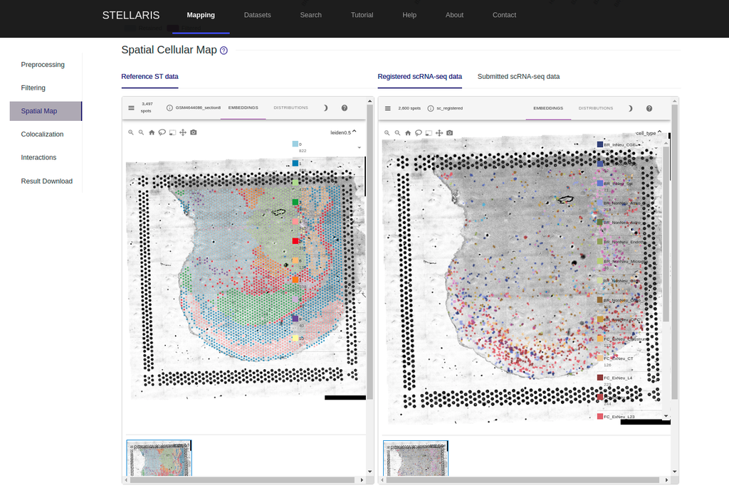

```python
adata_sc = sc.read_h5ad('./data/public/results/20221212/ac970aa0-79fd-11ed-968c-79eb53139108/sc_registered.h5ad')
```

```python
adata_sc.obs.index = [ re.sub('\\.',':',re.sub('X','',id)) for id in adata_sc.obs.index]
```

```python
adata_sc
```

```
AnnData object with n_obs × n_vars = 2600 × 52781
    obs: 'orig.ident', 'nCount_RNA', 'nFeature_RNA', 'cell_type', 'percent.mt', 'id', 'id_new', 'id_st', 'dist', 'x', 'y', 'x_noise', 'y_noise'
    var: 'name'
    obsm: 'spatial'
```

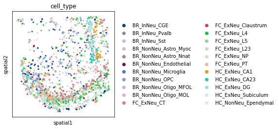

```python
sc.pl.spatial(adata_sc,color=['cell_type'],spot_size=50)
```